# 3η Εργασία - Υπολογιστική Νοημοσύνη

Εισαγωγή χρήσιμων Βιβλιοθηκών

```python
import tensorflow as tf
from tensorflow import keras
import matplotlib.pyplot as plt
import time
from sklearn.metrics import confusion_matrix, ConfusionMatrixDisplay, classification_report
import os
from keras.regularizers import l2
from keras.regularizers import l1
import tensorflow_addons as tfa
import keras_tuner as kt
import numpy as np
```

Εισαγωγή, κανονικοποίηση δεδομένων

```python
(x_train, y_train), (x_test, y_test) = keras.datasets.mnist.load_data()
y_test_r = y_test

x_train = keras.utils.normalize(x_train, axis=1)
x_test = keras.utils.normalize(x_test, axis=1)

#One-hot encoding (to increase performance)
y_train, y_test = keras.utils.to_categorical(y_train, 10), keras.utils.to_categorical(y_test, 10)
```

Αρχικοποίηση μοντέλου με δύο κρυφά στρώματα 128 και 256 νευρώνων αντίστοιχα. Συνάρτηση ενεργοποίησης ReLu, batch_size = 256, συνάρτηση στρώματος εξόδου η softmax. Τέλος ως μετρική αξιολόγησης θεωρείται η ακρίβεια accuracy, ενώ αντικειμενική συνάρτηση επιλέγεται η categorical cross-entropy.

```python
model = keras.models.Sequential()
model.add(keras.layers.Flatten(input_shape=(28,28)))
model.add(keras.layers.Dense(128, activation=tf.nn.relu))
model.add(keras.layers.Dense(256, activation=tf.nn.relu))
model.add(keras.layers.Dense(10, activation=tf.nn.softmax))

loss = keras.losses.CategoricalCrossentropy()
metrics = ['accuracy']
batch = 256
epochs = 100
validation_split = 0.2

path = "/home/alepetpan/Desktop/Computational_Intelligence/Project_3/images"
```

Μοντέλο με {1,256,Ν_train} - ((online, minibatch, batch))

```
Training time with minibatch = 1: 15394.713931560516
```

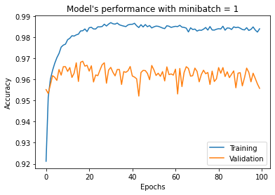

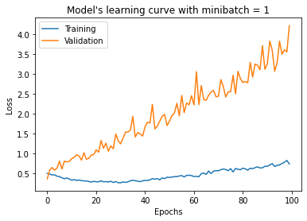

```
Training time with minibatch = 256: 176.12949132919312
```

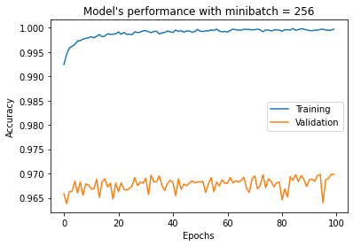

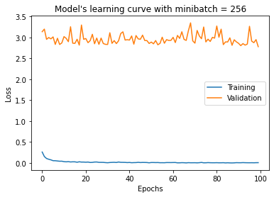

```
Training time with minibatch = 60000: 61.21163606643677
```

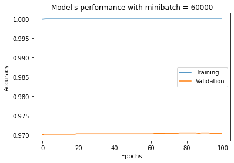

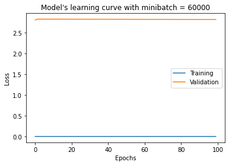

```python
# Run default model first
model.compile(loss=loss, metrics=metrics)
batch_size = [1, 256, x_train.shape[0]]
for b in batch_size:
    start = time.time()
    fit = model.fit(x_train, y_train, batch_size=b, epochs=epochs, validation_split=validation_split, verbose=1)
    training_time = time.time()-start

    #1 ταχύτητα εκπαίδευσης για τις τρείς διαφορετικές μεθόδους
    print(f"Training time with minibatch = {b}: {training_time}")
    #2 Καμπύλες ακρίβειας για training και validation set.
    plt.figure()
    plt.plot(fit.history['accuracy'], label='Training')
    plt.plot(fit.history['val_accuracy'], label='Validation')
    plt.xlabel('Epochs')
    plt.ylabel('Accuracy')
    plt.legend()
    plt.title(f"Model's performance with minibatch = {b}")
    plt.show()
    name = "performance_batch_"+str(b)+".png"
    full_path = fullpath = os.path.join(path, name)
    plt.savefig(full_path)
    plt.close()
    #2 Καμπύλες κόστους για training και validation set.
    plt.figure()
    plt.plot(fit.history['loss'], label='Training')
    plt.plot(fit.history['val_loss'], label='Validation')
    plt.xlabel('Epochs')
    plt.ylabel('Loss')
    plt.legend()
    plt.title(f"Model's learning curve with minibatch = {b}")
    plt.show()
    name = "learnCurve_batch_"+str(b)+".png"
    full_path = fullpath = os.path.join(path, name)
    plt.savefig(full_path)
    plt.close()
```

Μοντέλο με RMSProp optimizer με learning_rate = 0.001 και ρ = 0.01 ή 0.99

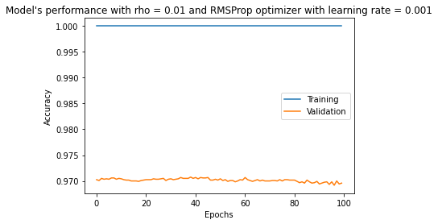

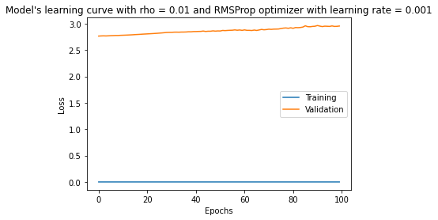

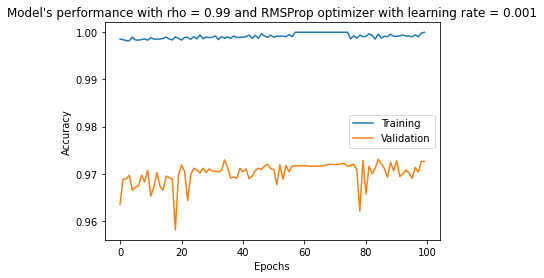

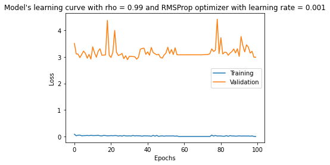

```python
# Run default model first
r = [0.01, 0.99]
for rho in r:
    optimizer = keras.optimizers.RMSprop(learning_rate=0.001, rho = rho)
    model.compile(optimizer=optimizer, loss=loss, metrics=metrics)
    fit = model.fit(x_train, y_train, batch_size=batch, epochs=epochs, validation_split=validation_split, verbose=1)

    #2 Καμπύλες ακρίβειας για training και validation set.
    plt.figure()
    plt.plot(fit.history['accuracy'], label='Training')
    plt.plot(fit.history['val_accuracy'], label='Validation')
    plt.xlabel('Epochs')
    plt.ylabel('Accuracy')
    plt.legend()
    plt.title(f"Model's performance with rho = {rho} and RMSProp optimizer with learning rate = 0.001")
    plt.show()
    name = "performance_rho_"+str(rho)+"_RMSProp_learnRate_0_001.png"
    full_path = fullpath = os.path.join(path, name)
    plt.savefig(full_path)
    plt.close()
    #2 Καμπύλες κόστους για training και validation set.
    plt.figure()
    plt.plot(fit.history['loss'], label='Training')
    plt.plot(fit.history['val_loss'], label='Validation')
    plt.xlabel('Epochs')
    plt.ylabel('Loss')
    plt.legend()
    plt.title(f"Model's learning curve with rho = {rho} and RMSProp optimizer with learning rate = 0.001")
    plt.show()
    name = "learnCurve_rho_"+str(rho)+"_RMSProp_learnRate_0_001.png"
    full_path = fullpath = os.path.join(path, name)
    plt.savefig(full_path)
    plt.close()
```

Μοντέλο με SGD optimizer με learning_rate = 0.01 και αρχικοποίηση των συναπτικών βαρών W κάθε στρώματος με βάση μια κανονική καταανομή με μ.ο. 10.

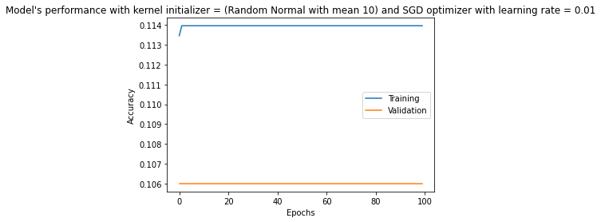

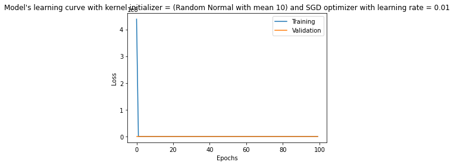

```python
optimizer = keras.optimizers.SGD(learning_rate=0.01)
initializer = keras.initializers.RandomNormal(mean=10)

model = keras.models.Sequential()
model.add(keras.layers.Flatten(input_shape=(28,28)))
model.add(keras.layers.Dense(128, activation=tf.nn.relu, kernel_initializer=initializer))
model.add(keras.layers.Dense(256, activation=tf.nn.relu, kernel_initializer=initializer))
model.add(keras.layers.Dense(10, activation=tf.nn.softmax))

model.compile(optimizer=optimizer, loss=loss, metrics=metrics)
fit = model.fit(x_train, y_train, batch_size=batch, epochs=epochs, validation_split=validation_split, verbose=1)

#2 Καμπύλες ακρίβειας για training και validation set.
plt.figure()
plt.plot(fit.history['accuracy'], label='Training')
plt.plot(fit.history['val_accuracy'], label='Validation')
plt.xlabel('Epochs')
plt.ylabel('Accuracy')
plt.legend()
plt.title(f"Model's performance with kernel initializer = (Random Normal with mean 10) and SGD optimizer with learning rate = 0.01")
plt.show()
name = "performance_kernelInit_RandomNorm_10_SGDOpt_learnRate_0_01.png"
full_path = fullpath = os.path.join(path, name)
plt.savefig(full_path)
plt.close()
#2 Καμπύλες κόστους για training και validation set.
plt.figure()
plt.plot(fit.history['loss'], label='Training')
plt.plot(fit.history['val_loss'], label='Validation')
plt.xlabel('Epochs')
plt.ylabel('Loss')
plt.legend()
plt.title(f"Model's learning curve with kernel initializer = (Random Normal with mean 10) and SGD optimizer with learning rate = 0.01")
plt.show()
name = "learnCurve_kernelInit_RandomNorm_10_SGDOpt_learnRate_0_01.png"
full_path = fullpath = os.path.join(path, name)
plt.savefig(full_path)
plt.close()
```

Ίδιες επιλογές με παραπάνω. Επιπλέον προσθήκη κανονικοποίησης με L2-νόρμα για τα συναπτικά βάρη κάθε στρώματος με παράμετρο κανονικοποίησης α = 0.1 ή 0.01 ή 0.001 Τρία μοντέλα με διαφορετικά batch μεγέθη, δύο μοντέλα με RMSProp optimizer και ένα με SGD optimizer.

```
Training time with minibatch = 1 and regularizer l2 with a = 0.1: 13711.509382009506
```

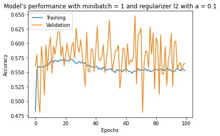

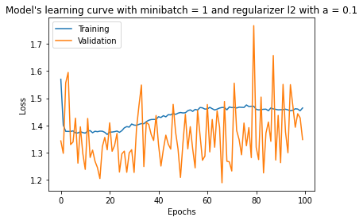

```
Training time with minibatch = 256 and regularizer l2 with a = 0.1: 139.20047450065613
```

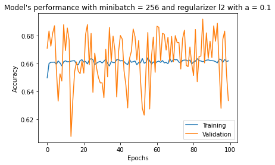

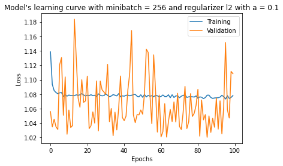

```
Training time with minibatch = 60000 and regularizer l2 with a = 0.1: 48.56872010231018
```

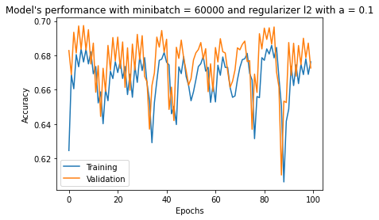

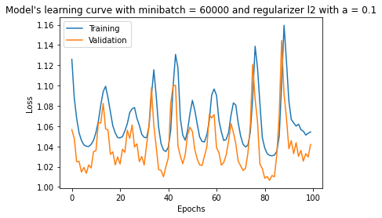

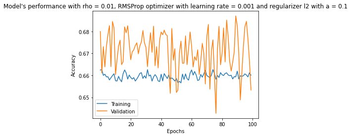

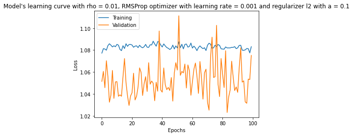

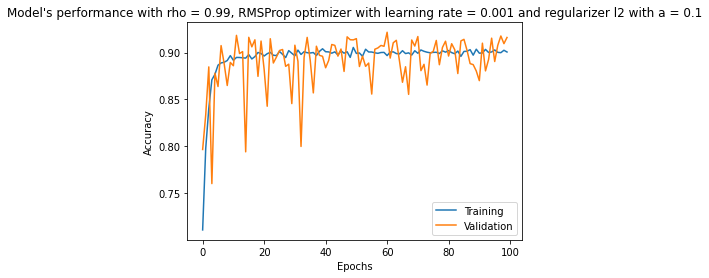

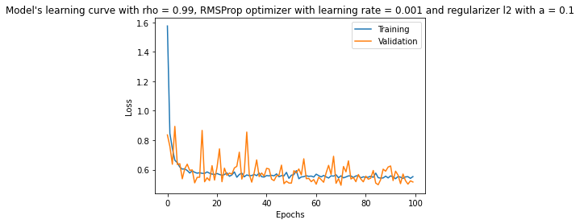

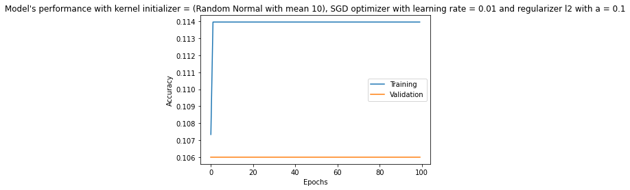

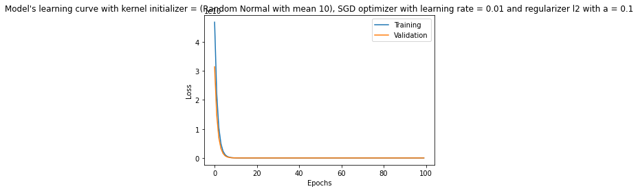

```
Training time with minibatch = 1 and regularizer l2 with a = 0.01: 14842.536232709885
```

[24 more figures not shown]

```python
a = [0.1, 0.01, 0.001]
for a in a:
    # Models with different batch sizes
    model = keras.models.Sequential()
    model.add(keras.layers.Flatten(input_shape=(28,28)))
    model.add(keras.layers.Dense(128, activation=tf.nn.relu, kernel_regularizer=l2(a)))
    model.add(keras.layers.Dense(256, activation=tf.nn.relu, kernel_regularizer=l2(a)))
    model.add(keras.layers.Dense(10, activation=tf.nn.softmax))
    model.compile(loss=loss, metrics=metrics)
    for b in batch_size:
        start = time.time()
        fit = model.fit(x_train, y_train, batch_size=b, epochs=epochs, validation_split=validation_split, verbose=1)
        training_time = time.time()-start

        #1 ταχύτητα εκπαίδευσης για τις τρείς διαφορετικές μεθόδους
        print(f"Training time with minibatch = {b} and regularizer l2 with a = {a}: {training_time}")
        #2 Καμπύλες ακρίβειας για training και validation set.
        plt.figure()
        plt.plot(fit.history['accuracy'], label='Training')
        plt.plot(fit.history['val_accuracy'], label='Validation')
        plt.xlabel('Epochs')
        plt.ylabel('Accuracy')
        plt.legend()
        plt.title(f"Model's performance with minibatch = {b} and regularizer l2 with a = {a}")
        plt.show()
        name = "performance_batch_"+str(b)+"_regularizer_l2_"+str(a)+".png"
        full_path = fullpath = os.path.join(path, name)
        plt.savefig(full_path)
        plt.close()
        #2 Καμπύλες κόστους για training και validation set.
        plt.figure()
        plt.plot(fit.history['loss'], label='Training')
        plt.plot(fit.history['val_loss'], label='Validation')
        plt.xlabel('Epochs')
        plt.ylabel('Loss')
        plt.legend()
        plt.title(f"Model's learning curve with minibatch = {b} and regularizer l2 with a = {a}")
        plt.show()
        name = "learnCurve_batch_"+str(b)+"_regularizer_l2_"+str(a)+".png"
        full_path = fullpath = os.path.join(path, name)
        plt.savefig(full_path)
        plt.close()

    # Models with RMSProp optimizers
    for rho in r:
        optimizer = keras.optimizers.RMSprop(learning_rate=0.001, rho = rho)
        model.compile(optimizer=optimizer, loss=loss, metrics=metrics)
        fit = model.fit(x_train, y_train, batch_size=batch, epochs=epochs, validation_split=validation_split, verbose=1)

        #2 Καμπύλες ακρίβειας για training και validation set.
        plt.figure()
        plt.plot(fit.history['accuracy'], label='Training')
        plt.plot(fit.history['val_accuracy'], label='Validation')
        plt.xlabel('Epochs')
        plt.ylabel('Accuracy')
        plt.legend()
        plt.title(f"Model's performance with rho = {rho}, RMSProp optimizer with learning rate = 0.001 and regularizer l2 with a = {a}")
        plt.show()
        name = "performance_rho_"+str(rho)+"_RMSProp_learnRate_0_001_regulizer_l2_"+str(a)+".png"
        full_path = fullpath = os.path.join(path, name)
        plt.savefig(full_path)
        plt.close()
        #2 Καμπύλες κόστους για training και validation set.
        plt.figure()
        plt.plot(fit.history['loss'], label='Training')
        plt.plot(fit.history['val_loss'], label='Validation')
        plt.xlabel('Epochs')
        plt.ylabel('Loss')
        plt.legend()
        plt.title(f"Model's learning curve with rho = {rho}, RMSProp optimizer with learning rate = 0.001 and regularizer l2 with a = {a}")
        plt.show()
        name = "learnCurve_rho_"+str(rho)+"_RMSProp_learnRate_0_001_regulizer_l2_"+str(a)+".png"
        full_path = fullpath = os.path.join(path, name)
        plt.savefig(full_path)
        plt.close()

    # Models with SGD optimizers
    optimizer = keras.optimizers.SGD(learning_rate=0.01)
    initializer = keras.initializers.RandomNormal(mean=10)

    model = keras.models.Sequential()
    model.add(keras.layers.Flatten(input_shape=(28,28)))
    model.add(keras.layers.Dense(128, activation=tf.nn.relu, kernel_initializer=initializer, kernel_regularizer=l2(a)))
    model.add(keras.layers.Dense(256, activation=tf.nn.relu, kernel_initializer=initializer, kernel_regularizer=l2(a)))
    model.add(keras.layers.Dense(10, activation=tf.nn.softmax))

    model.compile(optimizer=optimizer, loss=loss, metrics=metrics)
    fit = model.fit(x_train, y_train, batch_size=batch, epochs=epochs, validation_split=validation_split, verbose=1)

    #2 Καμπύλες ακρίβειας για training και validation set.
    plt.figure()
    plt.plot(fit.history['accuracy'], label='Training')
    plt.plot(fit.history['val_accuracy'], label='Validation')
    plt.xlabel('Epochs')
    plt.ylabel('Accuracy')
    plt.legend()
    plt.title(f"Model's performance with kernel initializer = (Random Normal with mean 10), SGD optimizer with learning rate = 0.01 and regularizer l2 with a = {a}")
    plt.show()
    name = "performance_kernelInit_RandomNorm_10_SGDOpt_learnRate_0_01_regulizer_l2_"+str(a)+".png"
    full_path = fullpath = os.path.join(path, name)
    plt.savefig(full_path)
    plt.close()
    #2 Καμπύλες κόστους για training και validation set.
    plt.figure()
    plt.plot(fit.history['loss'], label='Training')
    plt.plot(fit.history['val_loss'], label='Validation')
    plt.xlabel('Epochs')
    plt.ylabel('Loss')
    plt.legend()
    plt.title(f"Model's learning curve with kernel initializer = (Random Normal with mean 10), SGD optimizer with learning rate = 0.01 and regularizer l2 with a = {a}")
    plt.show()
    name = "learnCurve_kernelInit_RandomNorm_10_SGDOpt_learnRate_0_01_regulizer_l2_"+str(a)+".png"
    full_path = fullpath = os.path.join(path, name)
    plt.savefig(full_path)
    plt.close()
```

Κανονικοποίηση με L1-νόρμα για τα συναπτικά βάρη των στρωμάτων του δικτύου (α = 0.01) και ταυτόχρονη χρήση dropout με dropout probability = 0.3

[figure not shown]

[figure not shown]

```python
dropout_prob = 0.3
model = keras.models.Sequential()
model.add(keras.layers.Flatten(input_shape=(28,28)))
model.add(keras.layers.Dense(128, activation=tf.nn.relu, kernel_regularizer=l1(0.01)))
model.add(keras.layers.Dropout(dropout_prob))
model.add(keras.layers.Dense(256, activation=tf.nn.relu, kernel_regularizer=l1(0.01)))
model.add(keras.layers.Dropout(dropout_prob))
model.add(keras.layers.Dense(10, activation=tf.nn.softmax))
model.compile(loss=loss, metrics=metrics)
fit = model.fit(x_train, y_train, batch_size=batch, epochs=epochs, validation_split=validation_split, verbose=1)

#2 Καμπύλες ακρίβειας για training και validation set.
plt.figure()
plt.plot(fit.history['accuracy'], label='Training')
plt.plot(fit.history['val_accuracy'], label='Validation')
plt.xlabel('Epochs')
plt.ylabel('Accuracy')
plt.legend()
plt.title(f"Model's performance with regularizer l2 with a = 0.01 and dropout probability = 0.3")
plt.show()
name = "performance_regulizer_l1_0_01_drop_prob_0_3.png"
full_path = fullpath = os.path.join(path, name)
plt.savefig(full_path)
#2 Καμπύλες κόστους για training και validation set.
plt.figure()
plt.plot(fit.history['loss'], label='Training')
plt.plot(fit.history['val_loss'], label='Validation')
plt.xlabel('Epochs')
plt.ylabel('Loss')
plt.legend()
plt.title(f"Model's learning curve with regularizer l2 with a = 0.01 and dropout probability = 0.3")
plt.show()
name = "learnCurve_regulizer_l1_0_01_drop_prob_0_3.png"
full_path = fullpath = os.path.join(path, name)
plt.savefig(full_path)
plt.close()
```

Fine Tuning

Συνάρτηση η οποία δημιουργεί και επιστρέφει ένα Keras μοντέλο.

```python
# For F-measure
def build_model(hp):
    ''' Documentation on https://keras.io/keras_tuner/ '''
    n_h1 = hp.Choice('hidden1', [64, 128])
    n_h2 = hp.Choice('hidden2', [256, 512])
    a = hp.Choice('a', [0.1, 0.001, 0.000001])
    learning_rate = hp.Choice('learning_rate', [0.1, 0.01, 0.001])

    Heinitializer = keras.initializers.HeNormal()
    optimizer = keras.optimizers.RMSprop(learning_rate=learning_rate)
    metrics = [tfa.metrics.F1Score(10, 'macro')] # num_classes=10, ValueError=macro ## more on macro from https://www.tensorflow.org/addons/api_docs/python/tfa/metrics/F1Score

    model = keras.models.Sequential()
    model.add(keras.layers.Flatten(input_shape=(28,28)))
    model.add(keras.layers.Dense(n_h1, activation=tf.nn.relu, kernel_regularizer=l2(a),
             kernel_initializer=Heinitializer))
    model.add(keras.layers.Dense(n_h2, activation=tf.nn.relu, kernel_regularizer=l2(a),
             kernel_initializer=Heinitializer))
    model.add(keras.layers.Dense(10, activation=tf.nn.softmax))
    model.compile(optimizer=optimizer, loss=loss, metrics=metrics)

    return model
```

Αρχικοποίηση ενός tuner

```python
epochs = 1000
objective=kt.Objective('val_f1_score', direction = 'max')

tuner = kt.Hyperband(build_model, objective=objective, max_epochs=epochs)
```

```
INFO:tensorflow:Reloading Oracle from existing project ./untitled_project/oracle.json
INFO:tensorflow:Reloading Tuner from ./untitled_project/tuner0.json
```

Για επιτάχυνση της διαδικασίας χρησιμοποιείται η μέθοδος Early Stopping, χωρίς το βήμα της μετέπειτα επανεκπαίδευσης του δικτύου, με patience = 200 για κάθε ένα από τα εξεταζόμενα μοντέλα.

```python
early_stopping = [keras.callbacks.EarlyStopping(monitor='val_f1_score', mode='max', patience=200, verbose=1)]
```

Αναζήτηση βέλτιστων παραμέτρων

```python
tuner.search(x_train, y_train, epochs=epochs, validation_split=validation_split, callbacks=early_stopping)
best_params = tuner.get_best_hyperparameters(num_trials=1)[0]

print(f"Optimal number of neurons in 1st layer: {best_params.get('hidden1')}")
print(f"Optimal number of neurons in 2nd layer: {best_params.get('hidden2')}")
print(f"Optimal value of a for L2-regularization: {best_params.get('a')}")
print(f"Optimal value of learning rate: {best_params.get('learning_rate')}")
```

```
INFO:tensorflow:Oracle triggered exit
Optimal number of neurons in 1st layer: 128
Optimal number of neurons in 2nd layer: 256
Optimal value of a for L2-regularization: 1e-06
Optimal value of learning rate: 0.001
```

Εκπαίδευση του βέλτιστου Μοντέλου

```
Epoch 264: early stopping
```

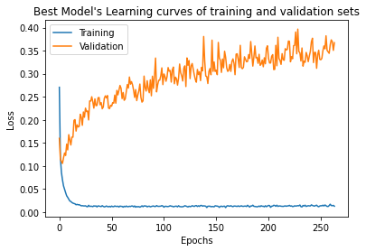

```python
model = tuner.hypermodel.build(best_params)
fit = model.fit(x_train, y_train, epochs=epochs, validation_split=validation_split, callbacks=early_stopping)

plt.figure()
plt.plot(fit.history['loss'],label='Training')
plt.plot(fit.history['val_loss'],label='Validation')
plt.xlabel('Epochs')
plt.ylabel('Loss')
plt.legend()
plt.title("Best Model's Learning curves of training and validation sets")
plt.show()
name = "learnCurve_BestModel.png"
full_path = fullpath = os.path.join(path, name)
plt.savefig(full_path)
plt.close()
```

Τελική αξιολόγηση γίνεται στο testing υποσύνολο

```
              precision    recall  f1-score   support

           0       0.98      0.99      0.98       980
           1       0.98      0.99      0.99      1135
           2       0.96      0.98      0.97      1032
           3       0.94      0.98      0.96      1010
           4       0.97      0.97      0.97       982
           5       0.99      0.93      0.96       892
           6       0.99      0.97      0.98       958
           7       0.97      0.97      0.97      1028
           8       0.96      0.96      0.96       974
           9       0.96      0.96      0.96      1009

    accuracy                           0.97     10000
   macro avg       0.97      0.97      0.97     10000
weighted avg       0.97      0.97      0.97     10000
```

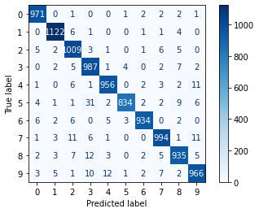

```python
y_pred = model.predict(x_test, verbose=1)
y_pred_b = np.argmax(y_pred, axis=1)


conf_matrix = confusion_matrix(y_test_r, y_pred_b)
conf_matrix_display = ConfusionMatrixDisplay(confusion_matrix=conf_matrix, display_labels=[0,1,2,3,4,5,6,7,8,9])
conf_matrix_display.plot(cmap=plt.cm.Blues)
plt.show

print(classification_report(y_test_r, y_pred_b))
```